# Homework10

Sam Rosenblatt

10/31/2018

# Number 1

Using a for loop, write a function to calculate the number of zeroes in a numeric vector. Before entering the loop, set up a counter variable counter <- 0. Inside the loop, add 1 to counter each time you have a zero in the matrix. Finally, use return(counter) for the output.

```r
CalculateZeros <- function(vec) {
  counter <-0
  for (i in 1:length(vec)){
    if (vec[i] == 0) counter <- counter+1
  }

 return(counter)
}


CalculateZeros(c(0,0,1,1,4,0))
```

```
## [1] 3
```

# Number 2

Use subsetting instead of a loop to rewrite the function as a single line of code.

```r
CalculateZerosSubsetting <- function(vec) {
  return(length((vec[vec==0])))
        }

CalculateZerosSubsetting(c(0,0,1,1,4,0))
```

```
## [1] 3
```

# Number 3

Write a function that takes as input two integers representing the number of rows and columns in a matrix. The output is a matrix of these dimensions in which each element is the product of the row number x the column number.

```r
number3 <- function(N, M) {
  mat <- matrix(nrow=N,ncol=M)
  for (i in 1:N) {
    for (j in 1:M) {
      mat[i, j] <- i*j
    }
  }

 return(mat)
}
number3(N=5,M= 3)
```

```
##      [,1] [,2] [,3]
## [1,]    1    2    3
## [2,]    2    4    6
## [3,]    3    6    9
## [4,]    4    8   12
## [5,]    5   10   15
```

# Number 4

Use the code from yesterday’s class to design and conduct a randomization test for some of your own data. You will need to modify the functions that read in the data, calculate the metric, and randomize the data. Once those are set up, the program should run correctly calling your new functions. Also, to make your analysis fully repeatable, make sure you set the random number seed at the beginning (use either set.seed() in base R, or char2seed in the TeachingDemos package

NOTE TO SELF: USE EXACT TESTS FOR MY OWN RESEARCH!!! WITH MEAN OF PROPORTIONS OF ONE STRATEGY AS THE METRIC https://en.wikipedia.org/wiki/Resampling_(statistics)#Permutation_tests

```r
####### ###########################################
# function: readData
# read in data set for analysis
# input: file name
# output: data frame version of the csv file you entered
#-------------------------------------------------
readData <- function(filename=NULL) {

  df <-read.table(file=filename,row.names=NULL,header=TRUE,sep=",",stringsAsFactors=FALSE)
return(df)
}
```

```r
##################################################
# function: shuffleData
# randomize data by randomly swapping half the data between the control and treatment groups
# input: data frame with your control as one variable and the treatment as the other
# output: dataframe where what is actually in each column is random
#-------------------------------------------------
shuffleData <- function(df) {
  data = df
  temp = df
  s = sample(1:(length(data[,1])), length(data[,1])/2, replace=F)
  data[,1] = c(data[-s,1], temp[s,2])
  data[,2] = c(data[-s, 2], temp[s, 1])
  # plot(data[,1])
  return(data)
}
```

```r
##################################################
# function: getPVal
# calculate p value from simulation
# input: list of observed metric, and vector of simulated metrics
# output: lower, upper tail probability values
#-------------------------------------------------
getPVal <- function(null_dist, obs_mean, n=1000){
  pLower <- length(null_dist[null_dist > obs_mean]) / n
  return(pLower)
}
```

```r
##################################################
# function: getMetric
# calculate metric for randomization test
# input: 2-column data frame
# output: null distribution
#-------------------------------------------------
getMetric <- function(data, n=1000) {
  . <- rep(-1, n)
  for (i in 1:n) {
    shuffled <- shuffleData(data)
    .[i] <-mean(shuffled[,1]) - mean(shuffled[,2])
  }
  return(.)
}
```

```r
##################################################
# function: plotRanTest
# create ggplot of histogram of simulated values
# input: list of observed metric and vector of simulated metrics
# output: saved ggplot graph
#-------------------------------------------------
library(ggplot2)

plotRanTest <- function(null_dist, obs_mean) {
  ggplot(data.frame(null_dist), aes(null_dist)) + geom_histogram(bins=50) +
    geom_vline(xintercept=obs_mean, col='orange', linetype='dashed')
}
```

```r
nSim <- 1000

dfM <- readData("csvVersionOfObsDictMcommaReplace.csv") #It was a ton of work to get this to function properly but that work is not reflected in the code as it was done using BBEdit and Python



sub <- c("X.AcqHH2..0.6..0.01.", "X.AcqGG2..0.6..0.01.") #These are the results of using two different targeted immunization strategies, one of which we consider the "control", for the same paramter set (60% of nodes unknown, 1% of the population immunized)
cntrlAndTreat <- dfM[sub]


set.seed(11235)
null_dist = getMetric(cntrlAndTreat, n=10000)
getPVal(null_dist, mean(cntrlAndTreat$X.AcqHH2..0.6..0.01.) - mean(cntrlAndTreat$X.AcqGG2..0.6..0.01.))
```

```
## [1] 0.114
```

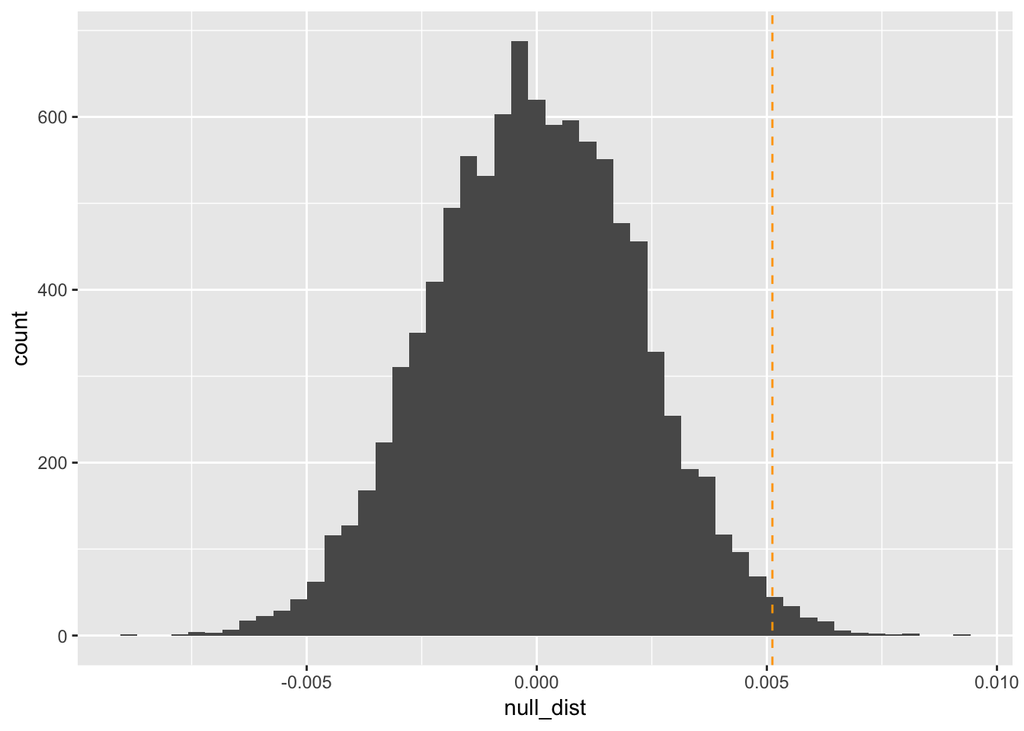

```r
plotRanTest(null_dist, mean(cntrlAndTreat$X.AcqHH2..0.6..0.01.) - mean(cntrlAndTreat$X.AcqGG2..0.6..0.01.))
```